# Section 0: Getting set up

Load all the packages you need, plus the `_common.R` source file.

# Section 1: Coefficient of Determination in a Regression

In the last class, we estimated a linear relationship between the size of fiddler grabs and latitude, and we recovered OLS estimates of $\hat\beta_0$ (the intercept) and $\hat\beta_1$ (the slope coefficient). From our correlation calculations, we also have a sense of the strength of these linear relationships. Here, we will use a concept that is very closely related to correlation to quantify the overall fit of our linear regression model.

Recall that the coefficient of determination, or $R^2$, is the share of the variance in $y$ that is explained by your regression model. Defining SSR as the sum of squared residuals (sum of the square of all our prediction errors) and SST as the total sum of squares (proportional to variance of $y$), we have:

$$R^{2}=1-\frac{S S R}{S S
T}=1-\frac{\sum_i e_i^2}{\sum_i(y_i-\bar{y})^2}$$

This is the most commonly cited measure of the fit of a regression model. $R^2$ ranges from 0 (my regression model explains none of the variation in $y$) to 1 (my regression model perfectly explains all variation in $y$).

Recall our regressions from last week:

$$\text{crab size} = \beta_0 + \beta_1
\text{latitude} + \epsilon$$
and:

$$\text{water temperature} = \beta_0 +
\beta_1 \text{latitude} + \epsilon$$
Recall the graphs of these relationships that we made last week:

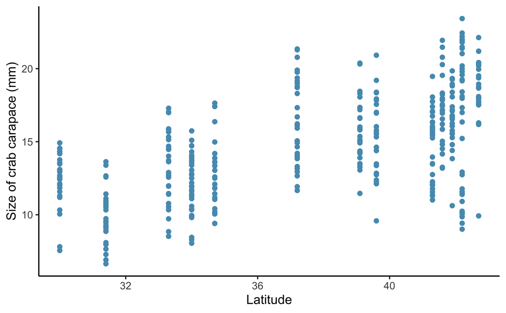

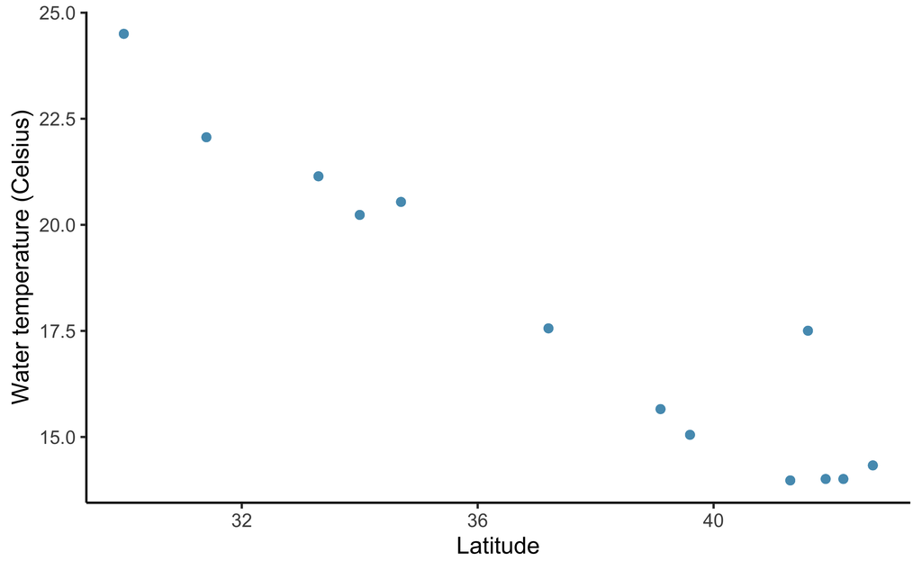

**Exercise**

1. Use the function `summary()` after the regression to calculate the $R^2$ for both the crab size and water temperature regressions. Recall that in the `pie_crab` dataset, `size` indicates crab carapace size, `latitude` is latitude of the sampling location, and `water_temp` is the water temperature at the sampling location.
2. Which regression model fits the data better? Is this what you expected based on the scatter plots? Why or why not?

**Answers**

```r
model_size <- lm(size~latitude, pie_crab)
summary(model_size)
```

```
#>
#> Call:
#> lm(formula = size ~ latitude, data = pie_crab)
#>
#> Residuals:
#>    Min     1Q Median     3Q    Max
#> -7.838 -1.880  0.114  1.948  6.928
#>
#> Coefficients:
#>             Estimate Std. Error t value            Pr(>|t|)
#> (Intercept)  -3.6244     1.2741   -2.84              0.0047 **
#> latitude      0.4851     0.0336   14.44 <0.0000000000000002 ***
#> ---
#> Signif. codes:  0 '***' 0.001 '**' 0.01 '*' 0.05 '.' 0.1 ' ' 1
#>
#> Residual standard error: 2.83 on 390 degrees of freedom
#> Multiple R-squared:  0.348,  Adjusted R-squared:  0.347
#> F-statistic:  209 on 1 and 390 DF,  p-value: <0.0000000000000002
```

```r
#0.348

model_temp <- lm(water_temp~latitude, pie_crab)
summary(model_temp)
```

```
#>
#> Call:
#> lm(formula = water_temp ~ latitude, data = pie_crab)
#>
#> Residuals:
#>    Min     1Q Median     3Q    Max
#> -1.120 -0.466 -0.265  0.555  2.879
#>
#> Coefficients:
#>             Estimate Std. Error t value            Pr(>|t|)
#> (Intercept)  46.7782     0.4490   104.2 <0.0000000000000002 ***
#> latitude     -0.7729     0.0118   -65.3 <0.0000000000000002 ***
#> ---
#> Signif. codes:  0 '***' 0.001 '**' 0.01 '*' 0.05 '.' 0.1 ' ' 1
#>
#> Residual standard error: 0.998 on 390 degrees of freedom
#> Multiple R-squared:  0.916,  Adjusted R-squared:  0.916
#> F-statistic: 4.26e+03 on 1 and 390 DF,  p-value: <0.0000000000000002
```

```r
#0.916
```

The regression model for water temperature and latitude fits the data better. This is what I expected based on the scatter plots because the data for water temperature ~ latitude followed a line, where the data for the size ~ latitude was a little more varied.

```r
SSR <- sum(model_size$residuals^2)

SST <- sum((pie_crab$size - mean(pie_crab$size))^2) #14.7

R2 <- 1- (SSR/SST)
R2
```

```
#> [1] 0.348
```

# Section 2: Categorical variables in Ordinary Least Square (OLS) Regressions

## Categorical Variables

In this section we will consider a situation where a numerical or a binary variable might not be useful for our needs.

We will use an example from the automobile industry where which has data on fuel efficiency and automobile characteristics for cars of two vintages: 1999 cars, and 2008 cars. We are interested here to understand how highway fuel economy differs across these two vintages. This is a policy relevant question – there has been increasing regulatory pressure to improve fuel efficiency in the US vehicle fleet over this time period. Did it work?

The dataset is called `mpg` and is pre-loaded in `R`.

**Step 1: Get your variables ready.**

Note that we want to treat the year of the car as a **categorical** variable, as we just have two years and we want to treat the 1999 cars as one “group” and the 2008 cars as another “group.” Take a moment to identify the class of the “year” variable, and then use the `as.factor()` command to turn it into a factor so we can trust `R` will treat it as a categorical variable:

```r
class(mpg$year)
```

```
#> [1] "integer"
```

```r
mpg$year_fct <- as.factor(mpg$year)
class(mpg$year_fct)
```

```
#> [1] "factor"
```

**Step 2: Visualize your data.**

As we showed in class, scatter plots are not all that helpful when we have a categorical variable. Use `geom_boxplot()` to plot “highway miles per gallon” (variable is called `hwy`) on the $y$-axis and vintage year on the $x$-axis. Do the distributions of fuel efficiency look different across the two groups?

```r
ggplot(mpg, aes(x= year_fct, y = hwy)) +
  geom_boxplot() +
  theme_minimal()

mpg %>%
  group_by(year) %>%
  summarize(median(hwy, na.rm = TRUE))
```

```
#> # A tibble: 2 × 2
#>    year `median(hwy, na.rm = TRUE)`
#>   <int>                       <int>
#> 1  1999                          25
#> 2  2008                          24
```

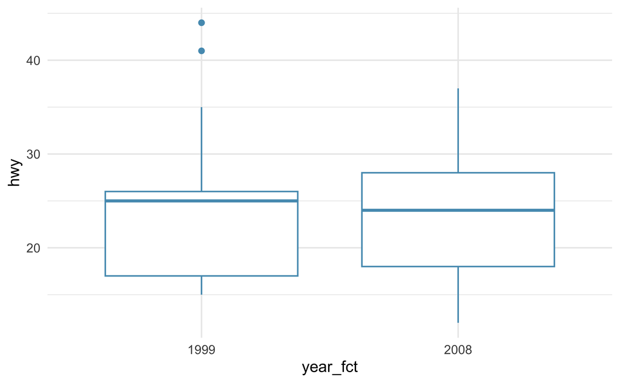

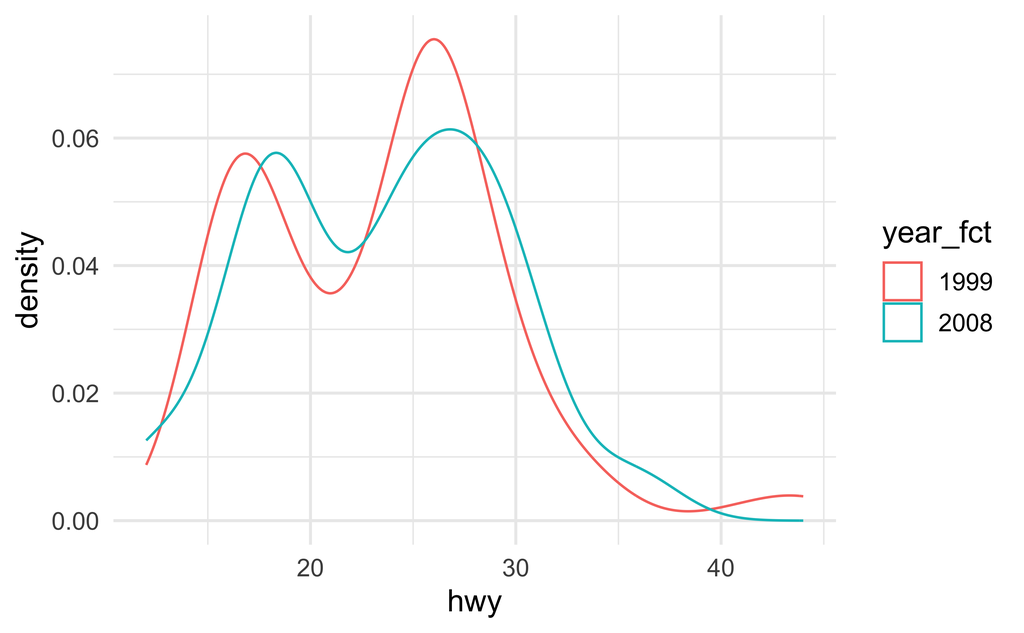

```r
# Medians pretty insensitive to outliers

ggplot(mpg, aes(x = hwy, color = year_fct)) +
  geom_density()
```

**Step 3: Run a regression.**

A linear regression will allow us to quantify the difference in average miles per gallon across the two car vintages. Note that in this case with a simple linear regression and one categorical variable with just two values (1999 and 2008), these regression estimates are equivalent to computing means for each group and differencing them.

Here is our regression:
$$hwy_i=\beta_{0}+\beta_{1} \cdot vintage_i
+\varepsilon_i$$
Complete the following:

1. Using the model specified above, use `lm()` to estimate $\hat\beta_0$ and $\hat\beta_1$ using this sample of data. Make sure you are treating `year` as a categorical variable! Use `summary(lm())`, `gt()` or `kable()` to visualize the regression results.
2. What does the intercept tell you, in words?